# HW 1

Reese Mullen

9-12-24

## 7.2 Fake-data simulation and regression:

Simulate 100 data points from the linear model, $y = a + bx$ + error, with $a = 5$, $b = 7$, the values of $x$ being sampled at random from a uniform distribution on the range $[0, 50]$, and errors that are normally distributed with mean 0 and standard deviation 3.

### 7.2a

Fit a regression line to these data and display the output.

```r
x1<-runif(100,0,50)
e1<-rnorm(100,0,3)
y1<-5+7*x1+e1
lm_1<-lm(y1~x1)
summary(lm_1)
```

```
##
## Call:
## lm(formula = y1 ~ x1)
##
## Residuals:
##     Min      1Q  Median      3Q     Max
## -5.7805 -2.4766 -0.1371  1.8119  6.1015
##
## Coefficients:
##             Estimate Std. Error t value Pr(>|t|)
## (Intercept)  4.26441    0.57284   7.444 3.81e-11 ***
## x1           7.03567    0.02012 349.734  < 2e-16 ***
## ---
## Signif. codes:  0 '***' 0.001 '**' 0.01 '*' 0.05 '.' 0.1 ' ' 1
##
## Residual standard error: 2.851 on 98 degrees of freedom
## Multiple R-squared:  0.9992, Adjusted R-squared:  0.9992
## F-statistic: 1.223e+05 on 1 and 98 DF,  p-value: < 2.2e-16
```

### 7.2b

Graph a scatterplot of the data and the regression line.

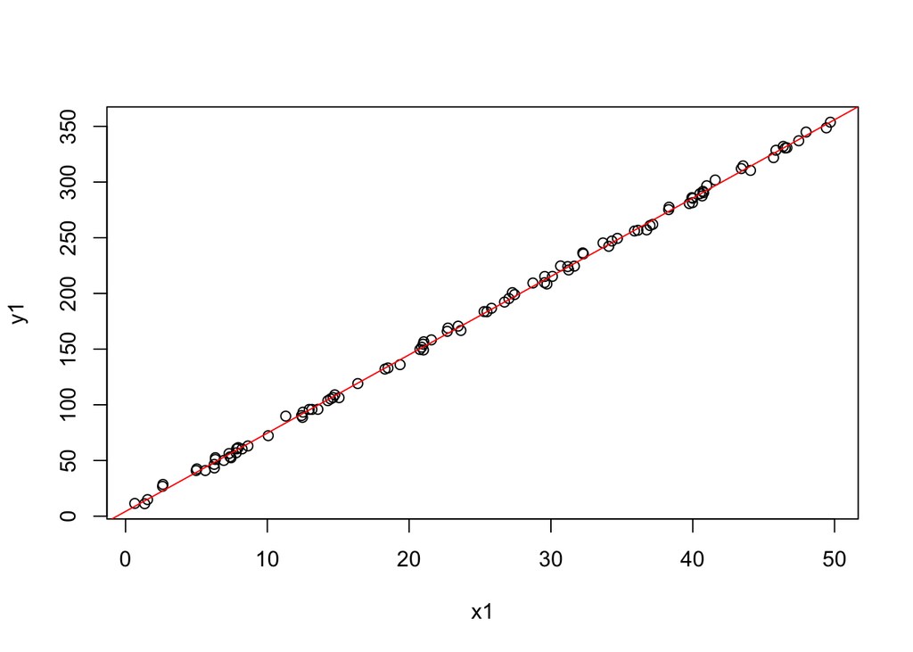

```r
plot(x1,y1)
abline(lm_1,col ="red")
```

### 7.2c

Use the `text` function in R to add the formula of the fitted line to the graph.

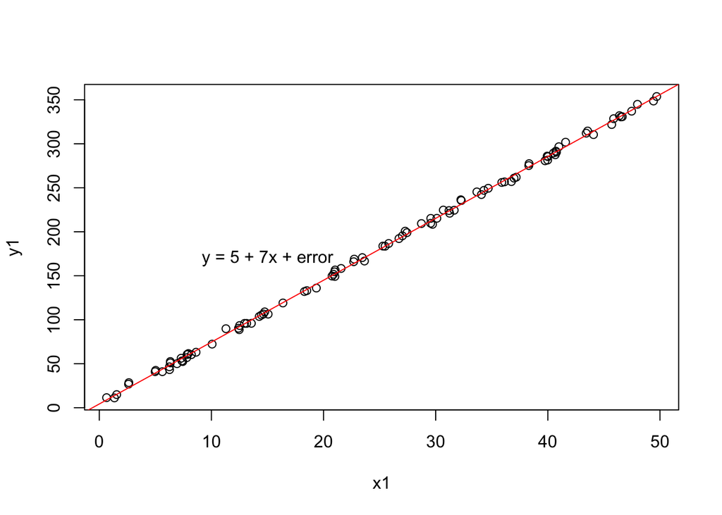

```r
plot(x1,y1)
abline(lm_1,col ="red")
text(x=15, y =170, "y = 5 + 7x + error")
```

## 7.3 Fake-data simulation and fitting the wrong model:

Simulate 100 data points from the model $y = a + b x + c x^2$ + error, with the values of $x$ being sampled at random from a uniform distribution on the range $[0, 50]$, errors that are normally distributed with mean 0 and standard deviation 3, and $a$, $b$, $c$ chosen so that a scatterplot of the data shows a clear nonlinear curve.

### 7.3 a

Fit a regression line `stan_glm(y ~ x)` to these data and display the output.

```r
x2 <-runif(100, 0, 50)
e2 <-rnorm(100, 0, 3)
y2<-10+1*x2+-0.1*x2^2+e2
stan_glm1<-rstanarm::stan_glm(y2~x2)
summary(stan_glm1)
```

```
##
## Model Info:
##  function:     stan_glm
##  family:       gaussian [identity]
##  formula:      y2 ~ x2
##  algorithm:    sampling
##  sample:       4000 (posterior sample size)
##  priors:       see help('prior_summary')
##  observations: 100
##  predictors:   2
##
## Estimates:
##               mean   sd   10%   50%   90%
## (Intercept) 51.0    4.0 45.9  51.1  56.2
## x2          -4.1    0.1 -4.2  -4.1  -3.9
## sigma       20.6    1.5 18.8  20.5  22.6
##
## Fit Diagnostics:
##            mean   sd    10%   50%   90%
## mean_PPD -51.7    3.0 -55.5 -51.8 -47.9
##
## The mean_ppd is the sample average posterior predictive distribution of the outcome variable (for details see help('summary.stanreg')).
##
## MCMC diagnostics
##               mcse Rhat n_eff
## (Intercept)   0.1  1.0  3902
## x2            0.0  1.0  3743
## sigma         0.0  1.0  3267
## mean_PPD      0.0  1.0  3879
## log-posterior 0.0  1.0  1709
##
## For each parameter, mcse is Monte Carlo standard error, n_eff is a crude measure of effective sample size, and Rhat is the potential scale reduction factor on split chains (at convergence Rhat=1).
```

### 7.3b

Graph a scatterplot of the data and the regression line. This is the best-fit linear regression. What does “best-fit” mean in this context? Best fit in this context refers to closest linear approximation of the model although that does not define the true shape of our data.

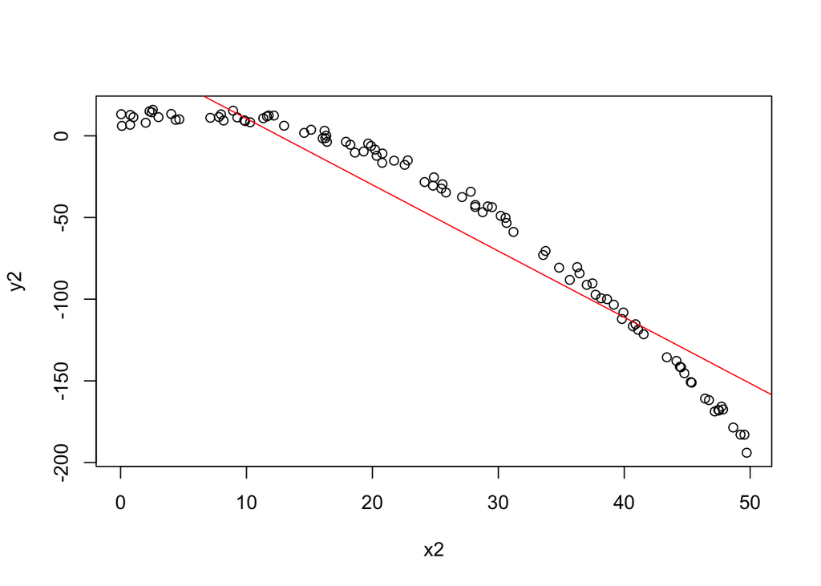

```r
plot(x2,y2)
abline(stan_glm1, col = "red")
```

## 7.6 Formulating comparisons as regression models:

Take the election forecasting model and simplify it by creating a binary predictor defined as $x = 0$ if income growth is less than 2% and $x = 1$ if income growth is more than 2%.

```r
elect <- read.table("~/Downloads/hibbs.dat", header = TRUE)
x7.6 <- ifelse(elect$growth > 2, 1, 0)
```

### 7.6a

Compute the difference in incumbent party’s vote share on average, comparing those two groups of elections, and determine the standard error for this difference.

```r
incumb_over<- subset(elect, x7.6 ==1)
incumb_under<- subset(elect, x7.6 == 0)
mean_over<-mean(incumb_over$vote)
mean_under<-mean(incumb_under$vote)

diff<- mean_over-mean_under

se_over<-sd(incumb_over$vote)/sqrt(nrow(incumb_over))
se_under<-sd(incumb_under$vote)/sqrt(nrow(incumb_under))
```

### 7.6b

Regress incumbent party’s vote share on the binary predictor of income growth and check that the resulting estimate and standard error are the same as above.

```r
model7.6<-lm(elect$vote~x7.6)
summary(model7.6)
```

```
##
## Call:
## lm(formula = elect$vote ~ x7.6)
##
## Residuals:
##      Min       1Q   Median       3Q      Max
## -10.2087  -3.3706   0.1287   3.3037   6.9812
##
## Coefficients:
##             Estimate Std. Error t value Pr(>|t|)
## (Intercept)   49.301      1.769  27.866 1.15e-13 ***
## x7.6           5.508      2.502   2.201    0.045 *
## ---
## Signif. codes:  0 '***' 0.001 '**' 0.01 '*' 0.05 '.' 0.1 ' ' 1
##
## Residual standard error: 5.004 on 14 degrees of freedom
## Multiple R-squared:  0.2571, Adjusted R-squared:  0.204
## F-statistic: 4.845 on 1 and 14 DF,  p-value: 0.045
```

## 8.8 Comparing lm and stan_glm:

Use simulated data to compare least squares estimation to default Bayesian regression:

### 8.8a

Simulate 100 data points from the model, $y = 2 + 3x$ + error, with predictors $x$ drawn from a uniform distribution from 0 to 20 and with independent errors drawn from the normal distribution with mean 0 and standard deviation 5. Fit the regression of $y$ on $x$ data using `lm` and `stan_glm` (using its default settings) and check that the two programs give nearly identical results.

```r
x3<-runif(100,0,20)
e3<-rnorm(100,0,5)
y3<- 2+3*x3+e3
lm_2<-lm(y3~x3)
stan_glm2<-rstanarm::stan_glm(y3~x3)
summary(lm_2)
```

```
##
## Call:
## lm(formula = y3 ~ x3)
##
## Residuals:
##      Min       1Q   Median       3Q      Max
## -16.0700  -2.8232  -0.1943   3.7400  13.8459
##
## Coefficients:
##             Estimate Std. Error t value Pr(>|t|)
## (Intercept)   2.9203     1.1409    2.56    0.012 *
## x3            2.9415     0.0963   30.55   <2e-16 ***
## ---
## Signif. codes:  0 '***' 0.001 '**' 0.01 '*' 0.05 '.' 0.1 ' ' 1
##
## Residual standard error: 5.31 on 98 degrees of freedom
## Multiple R-squared:  0.905,  Adjusted R-squared:  0.904
## F-statistic:   933 on 1 and 98 DF,  p-value: < 2.2e-16
```

```r
summary(stan_glm2)
```

```
##
## Model Info:
##  function:     stan_glm
##  family:       gaussian [identity]
##  formula:      y3 ~ x3
##  algorithm:    sampling
##  sample:       4000 (posterior sample size)
##  priors:       see help('prior_summary')
##  observations: 100
##  predictors:   2
##
## Estimates:
##               mean   sd   10%   50%   90%
## (Intercept) 2.9    1.2  1.4   2.9   4.4
## x3          2.9    0.1  2.8   2.9   3.1
## sigma       5.4    0.4  4.9   5.3   5.9
##
## Fit Diagnostics:
##            mean   sd   10%   50%   90%
## mean_PPD 33.8    0.8 32.8  33.8  34.7
##
## The mean_ppd is the sample average posterior predictive distribution of the outcome variable (for details see help('summary.stanreg')).
##
## MCMC diagnostics
##               mcse Rhat n_eff
## (Intercept)   0.0  1.0  4049
## x3            0.0  1.0  4219
## sigma         0.0  1.0  3944
## mean_PPD      0.0  1.0  3767
## log-posterior 0.0  1.0  1759
##
## For each parameter, mcse is Monte Carlo standard error, n_eff is a crude measure of effective sample size, and Rhat is the potential scale reduction factor on split chains (at convergence Rhat=1).
```

### 8.8b

Plot the simulated data and the two fitted regression lines.

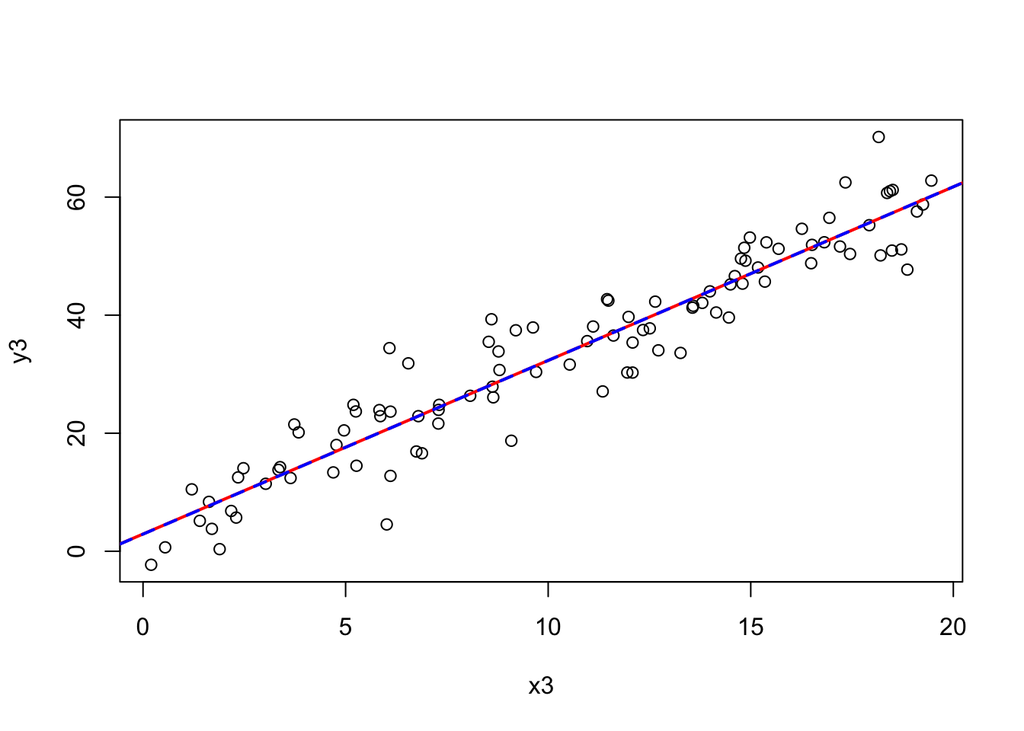

```r
plot(x3, y3)
abline(lm_2, col = "red", lwd = 2, lty = 1)
abline(a = coef(stan_glm2)[1], b = coef(stan_glm2)[2], col = "blue", lwd = 2, lty = 2)
```

### 8.8c

Repeat the two steps above, but try to create conditions for your simulation so that `lm` and `stan_glm` give much different results.

```r
x4<-runif(10,0,20)
e4<-rnorm(10,0,1000)
y4<- 2+3*x4+e4
lm_3<-lm(y4~x4)
stan_glm3<-rstanarm::stan_glm(y4~x4)
summary(lm_3)
```

```
##
## Call:
## lm(formula = y4 ~ x4)
##
## Residuals:
##      Min       1Q   Median       3Q      Max
## -1113.52  -882.26  -310.12    11.49  2778.46
##
## Coefficients:
##              Estimate Std. Error t value Pr(>|t|)
## (Intercept)   95.4858  1206.4536   0.079    0.939
## x4            -0.2586    98.3715  -0.003    0.998
##
## Residual standard error: 1323 on 8 degrees of freedom
## Multiple R-squared:  8.639e-07,  Adjusted R-squared:  -0.125
## F-statistic: 6.911e-06 on 1 and 8 DF,  p-value: 0.998
```

```r
summary(stan_glm3)
```

```
##
## Model Info:
##  function:     stan_glm
##  family:       gaussian [identity]
##  formula:      y4 ~ x4
##  algorithm:    sampling
##  sample:       4000 (posterior sample size)
##  priors:       see help('prior_summary')
##  observations: 10
##  predictors:   2
##
## Estimates:
##               mean    sd      10%     50%     90%
## (Intercept)    84.6  1324.3 -1533.0    74.0  1704.5
## x4              0.8   109.0  -133.4     2.2   134.7
## sigma        1434.8   392.8  1017.0  1358.8  1934.4
##
## Fit Diagnostics:
##            mean   sd     10%    50%    90%
## mean_PPD   97.3  658.8 -711.1   97.7  908.0
##
## The mean_ppd is the sample average posterior predictive distribution of the outcome variable (for details see help('summary.stanreg')).
##
## MCMC diagnostics
##               mcse Rhat n_eff
## (Intercept)   26.6  1.0 2482
## x4             2.2  1.0 2467
## sigma          8.9  1.0 1967
## mean_PPD      12.4  1.0 2831
## log-posterior  0.0  1.0 1244
##
## For each parameter, mcse is Monte Carlo standard error, n_eff is a crude measure of effective sample size, and Rhat is the potential scale reduction factor on split chains (at convergence Rhat=1).
```

## 10.1 Regression with interactions:

Simulate 100 data points from the model, $y = b_0 + b_1 x + b_2 z + b_3 x z$ + error, with a continuous predictor $x$ and a binary predictor $z$, coefficients $b = c(1, 2, -1, -2)$, and errors drawn independently from a normal distribution with mean 0 and standard deviation 3, as follows. For each data point $i$, first draw $z_i$, equally likely to take on the values 0 and 1. Then draw $x_i$ from a normal distribution with mean $z_i$ and standard deviation 1. Then draw the error from its normal distribution and compute $y_i$.

### 10.1a

Display your simulated data as a graph of $y$ vs $x$, using dots and circles for the points with $z$ = 0 and 1, respectively.

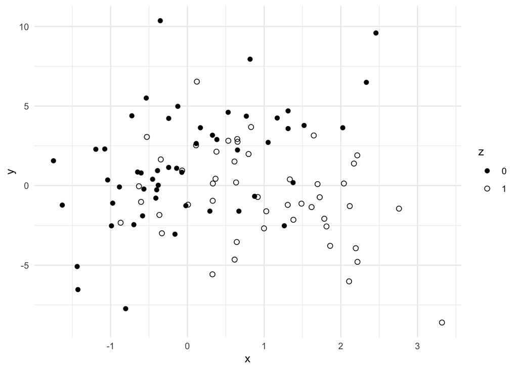

```r
b0 <- 1
b1 <- 2
b2 <- -1
b3 <- -2
z<-rbinom(100, 1, 0.5)
x5<-rnorm(100, mean = z, sd = 1)
e5<-rnorm(100, mean = 0, sd = 3)
y5 <- b0 + b1 * x5 + b2 * z + b3 * x5 * z + e5

Q10.1<-data.frame(x = x5, y = y5, z = as.factor(z))
ggplot(Q10.1, aes(x = x, y = y, shape = z)) +
  geom_point(size = 2) +
  scale_shape_manual(values = c(16, 1)) +
  theme_minimal()
```

### 10.1b

Fit a regression predicting $y$ from $x$ and $z$ with no interaction. Make a graph with the data and two parallel lines showing the fitted model.

```r
model10.1b <- lm(y5 ~ x5 + z, data = Q10.1)
summary(model10.1b)
```

```
##
## Call:
## lm(formula = y5 ~ x5 + z, data = Q10.1)
##
## Residuals:
##     Min      1Q  Median      3Q     Max
## -9.0695 -1.8429 -0.1308  2.0766  9.1478
##
## Coefficients:
##             Estimate Std. Error t value Pr(>|t|)
## (Intercept)   1.3773     0.4520   3.047  0.00297 **
## x5            0.4603     0.3307   1.392  0.16711
## z1           -2.4413     0.7238  -3.373  0.00107 **
## ---
## Signif. codes:  0 '***' 0.001 '**' 0.01 '*' 0.05 '.' 0.1 ' ' 1
##
## Residual standard error: 3.259 on 97 degrees of freedom
## Multiple R-squared:  0.105,  Adjusted R-squared:  0.08658
## F-statistic: 5.692 on 2 and 97 DF,  p-value: 0.004599
```

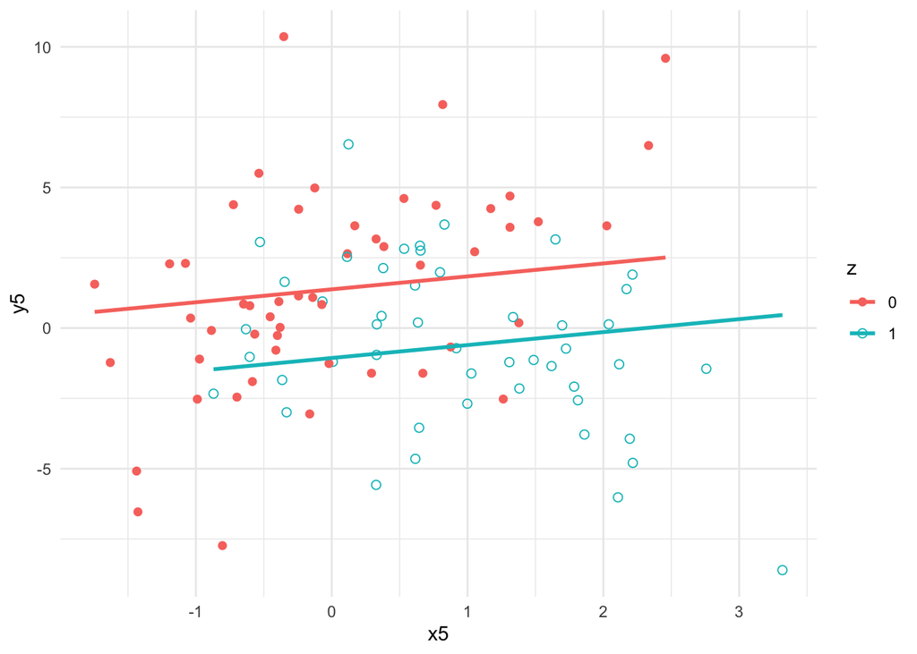

```r
Q10.1$pred1<- predict(model10.1b)
ggplot(Q10.1, aes(x = x5, y = y5, shape = z, color = z)) +
  geom_point(size = 2) +
  geom_smooth(method = "lm", aes(y = pred1), se = FALSE) +
  scale_shape_manual(values = c(16, 1)) +
  theme_minimal()
```

### 10.1c

Fit a regression predicting $y$ from $x$, $z$, and their interaction. Make a graph with the data and two lines showing the fitted model.

```r
model10.1c <- lm(y5 ~ x5 * z, data = Q10.1)
summary(model10.1c)
```

```
##
## Call:
## lm(formula = y5 ~ x5 * z, data = Q10.1)
##
## Residuals:
##     Min      1Q  Median      3Q     Max
## -7.6615 -2.0207  0.0726  1.8060  9.6285
##
## Coefficients:
##             Estimate Std. Error t value Pr(>|t|)
## (Intercept)   1.3651     0.4094   3.335  0.00122 **
## x5            1.7873     0.4110   4.349 3.41e-05 ***
## z1           -0.9898     0.7242  -1.367  0.17490
## x5:z1        -2.8306     0.6002  -4.716 8.16e-06 ***
## ---
## Signif. codes:  0 '***' 0.001 '**' 0.01 '*' 0.05 '.' 0.1 ' ' 1
##
## Residual standard error: 2.952 on 96 degrees of freedom
## Multiple R-squared:  0.2734, Adjusted R-squared:  0.2507
## F-statistic: 12.04 on 3 and 96 DF,  p-value: 9.317e-07
```

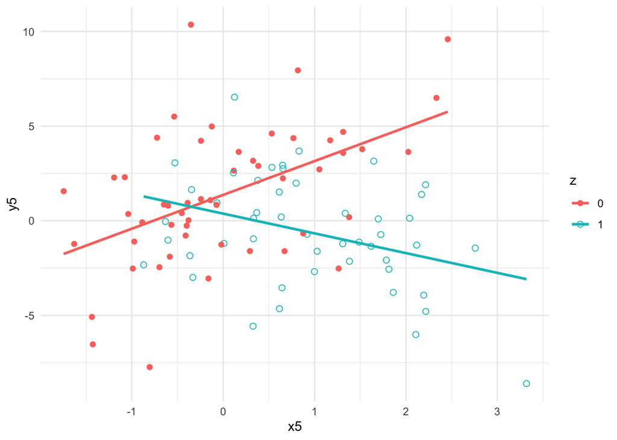

```r
Q10.1$pred2<- predict(model10.1c)
ggplot(Q10.1, aes(x = x5, y = y5, shape = z, color = z)) +
  geom_point(size = 2) +
  geom_smooth(method = "lm", aes(y = pred2), se = FALSE) +
  scale_shape_manual(values = c(16, 1)) +
  theme_minimal()
```

## 10.2 Regression with interactions:

Here is the output from a fitted linear regression of outcome $y$ on pre-treatment predictor $x$, treatment indicator $z$, and their interaction:

```
            Mediam MAD_SD
(Intercept) 1.2    0.2
x           1.6    0.4
z           2.7    0.3
x:z         0.7    0.5

Auxiliary parameter(s):
      Median MAD_SD
sigma 0.4    0.0
```

### 10.2a

Write the equation of the estimated regression line of $y$ on $x$ for the treatment group and the control group, and the equation of the estimated regression line of $y$ on $x$ for the control group.

```r
#Control Group
#$y$ = 1.2 + 1.6 $x$ + error

#Treatment Group
# $y$ = 3.9 + 2.3 $x$ + error
```

### 10.2b

Graph with pen on paper the two regression lines, assuming the values of $x$ fall in the range $(0, 10)$. On this graph also include a scatterplot of data (using open circles for treated units and dots for controls) that are consistent with the fitted model.

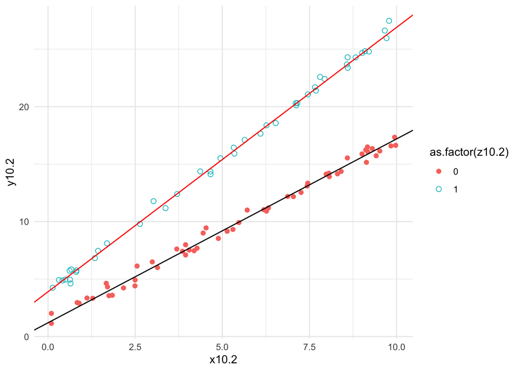

```r
b0_con<-1.2
b1_con<-1.6
b0_treat<-3.9
b1_treat<-2.3
sigma<-0.4

x10.2<- runif(100, 0, 10)
z10.2 <- rbinom(100, 1, 0.5)
y10.2 <- ifelse(z10.2 == 0,
            b0_con + b1_con * x10.2 + rnorm(100, 0, sigma),
            b0_treat + b1_treat * x10.2 + rnorm(100, 0, sigma))

Q10.2 <- data.frame(x = x10.2, y = y10.2, z = as.factor(z10.2))

ggplot(Q10.2, aes(x = x10.2, y = y10.2, color = as.factor(z10.2), shape = as.factor(z10.2))) +
  geom_point(size = 2) +
  geom_abline(intercept = b0_con, slope = b1_con) +
  geom_abline(intercept = b0_treat, slope = b1_treat,color = "red") +
  scale_shape_manual(values = c(16, 1)) +
  theme_minimal()
```

## 10.5 Regression modeling and prediction:

The folder `KidIQ` contains a subset of the children and mother data discussed earlier in the chapter. You have access to children’s test scores at age 3, mother’s education, and the mother’s age at the time she gave birth for a sample of 400 children.

```r
KidIQ<-read.csv("child_iq.csv")
```

### 10.5a

Fit a regression of child test scores on mother’s age, display the data and fitted model, check assumptions, and interpret the slope coefficient. Based on this analysis, when do you recommend mothers should give birth? What are you assuming in making this recommendation?

The initial model has a Y intercept of 67.78 for the childrens’ test scores. However, this does not make sense because the mother’s in our data are all between the age of 17 and 29. When we center the data around the mean the intercept becomes 86.93. The slope stays the same at 0.84 increase for each year older that the mother is when she gives birth. The recommendation would be for the mother to give birth at age 29 as this is the highest datapoint that our model predicts. This model assumes that other factors such as education have no impact on the childrens’ testing.

```r
model10.5a1<-lm(ppvt~momage, data = KidIQ)
summary(model10.5a1)
```

```
##
## Call:
## lm(formula = ppvt ~ momage, data = KidIQ)
##
## Residuals:
##     Min      1Q  Median      3Q     Max
## -67.109 -11.798   2.971  14.860  55.210
##
## Coefficients:
##             Estimate Std. Error t value Pr(>|t|)
## (Intercept)  67.7827     8.6880   7.802 5.42e-14 ***
## momage        0.8403     0.3786   2.219    0.027 *
## ---
## Signif. codes:  0 '***' 0.001 '**' 0.01 '*' 0.05 '.' 0.1 ' ' 1
##
## Residual standard error: 20.34 on 398 degrees of freedom
## Multiple R-squared:  0.01223,    Adjusted R-squared:  0.009743
## F-statistic: 4.926 on 1 and 398 DF,  p-value: 0.02702
```

```r
mean(KidIQ$momage)
```

```
## [1] 22.79
```

```r
KidIQ$cent_momage<-KidIQ$momage-mean(KidIQ$momage)

model10.5a2<-lm(ppvt~cent_momage, data = KidIQ)
summary(model10.5a2)
```

```
##
## Call:
## lm(formula = ppvt ~ cent_momage, data = KidIQ)
##
## Residuals:
##     Min      1Q  Median      3Q     Max
## -67.109 -11.798   2.971  14.860  55.210
##
## Coefficients:
##             Estimate Std. Error t value Pr(>|t|)
## (Intercept)  86.9325     1.0170  85.478   <2e-16 ***
## cent_momage   0.8403     0.3786   2.219    0.027 *
## ---
## Signif. codes:  0 '***' 0.001 '**' 0.01 '*' 0.05 '.' 0.1 ' ' 1
##
## Residual standard error: 20.34 on 398 degrees of freedom
## Multiple R-squared:  0.01223,    Adjusted R-squared:  0.009743
## F-statistic: 4.926 on 1 and 398 DF,  p-value: 0.02702
```

### 10.5b

Repeat this for a regression that further includes mother’s education, interpreting both slope coefficients in this model. Have your conclusions about the timing of birth changed? For each year older that the mother is when she gives borth the child’s test score increases by 0.34 points on average. For each education level that the mother has obtained, the child’s scores increases by 4.71 on average. The mother’s ages no longer has a significant p-value and we can say that education of the mother is actually far more impactful on the child’s score.

```r
model10.5b1<-lm(ppvt~momage+educ_cat, data = KidIQ)
summary(model10.5b1)
```

```
##
## Call:
## lm(formula = ppvt ~ momage + educ_cat, data = KidIQ)
##
## Residuals:
##     Min      1Q  Median      3Q     Max
## -61.763 -13.130   2.495  14.620  55.610
##
## Coefficients:
##             Estimate Std. Error t value Pr(>|t|)
## (Intercept)  69.1554     8.5706   8.069 8.51e-15 ***
## momage        0.3433     0.3981   0.862 0.389003
## educ_cat      4.7114     1.3165   3.579 0.000388 ***
## ---
## Signif. codes:  0 '***' 0.001 '**' 0.01 '*' 0.05 '.' 0.1 ' ' 1
##
## Residual standard error: 20.05 on 397 degrees of freedom
## Multiple R-squared:  0.04309,    Adjusted R-squared:  0.03827
## F-statistic: 8.939 on 2 and 397 DF,  p-value: 0.0001594
```

```r
model10.5b2<-lm(ppvt~cent_momage+educ_cat, data = KidIQ)
summary(model10.5b2)
```

```
##
## Call:
## lm(formula = ppvt ~ cent_momage + educ_cat, data = KidIQ)
##
## Residuals:
##     Min      1Q  Median      3Q     Max
## -61.763 -13.130   2.495  14.620  55.610
##
## Coefficients:
##             Estimate Std. Error t value Pr(>|t|)
## (Intercept)  76.9797     2.9562  26.040  < 2e-16 ***
## cent_momage   0.3433     0.3981   0.862 0.389003
## educ_cat      4.7114     1.3165   3.579 0.000388 ***
## ---
## Signif. codes:  0 '***' 0.001 '**' 0.01 '*' 0.05 '.' 0.1 ' ' 1
##
## Residual standard error: 20.05 on 397 degrees of freedom
## Multiple R-squared:  0.04309,    Adjusted R-squared:  0.03827
## F-statistic: 8.939 on 2 and 397 DF,  p-value: 0.0001594
```

### 10.5c

Now create an indicator variable reflecting whether the mother has completed high school or not. Consider interactions between high school completion and mother’s age. Also create a plot that shows the separate regression lines for each high school completion status group.

```r
KidIQ$MomHS<- ifelse(KidIQ$educ_cat >=2, 1, 0)
model10.5c <- lm(ppvt ~ momage * MomHS, data = KidIQ)

summary(model10.5c)
```

```
##
## Call:
## lm(formula = ppvt ~ momage * MomHS, data = KidIQ)
##
## Residuals:
##     Min      1Q  Median      3Q     Max
## -56.696 -12.407   2.022  14.804  54.343
##
## Coefficients:
##              Estimate Std. Error t value Pr(>|t|)
## (Intercept)  105.2202    17.6454   5.963 5.49e-09 ***
## momage        -1.2402     0.8113  -1.529   0.1271
## MomHS        -38.4088    20.2815  -1.894   0.0590 .
## momage:MomHS   2.2097     0.9181   2.407   0.0165 *
## ---
## Signif. codes:  0 '***' 0.001 '**' 0.01 '*' 0.05 '.' 0.1 ' ' 1
##
## Residual standard error: 19.85 on 396 degrees of freedom
## Multiple R-squared:  0.06417,    Adjusted R-squared:  0.05708
## F-statistic: 9.051 on 3 and 396 DF,  p-value: 8.276e-06
```

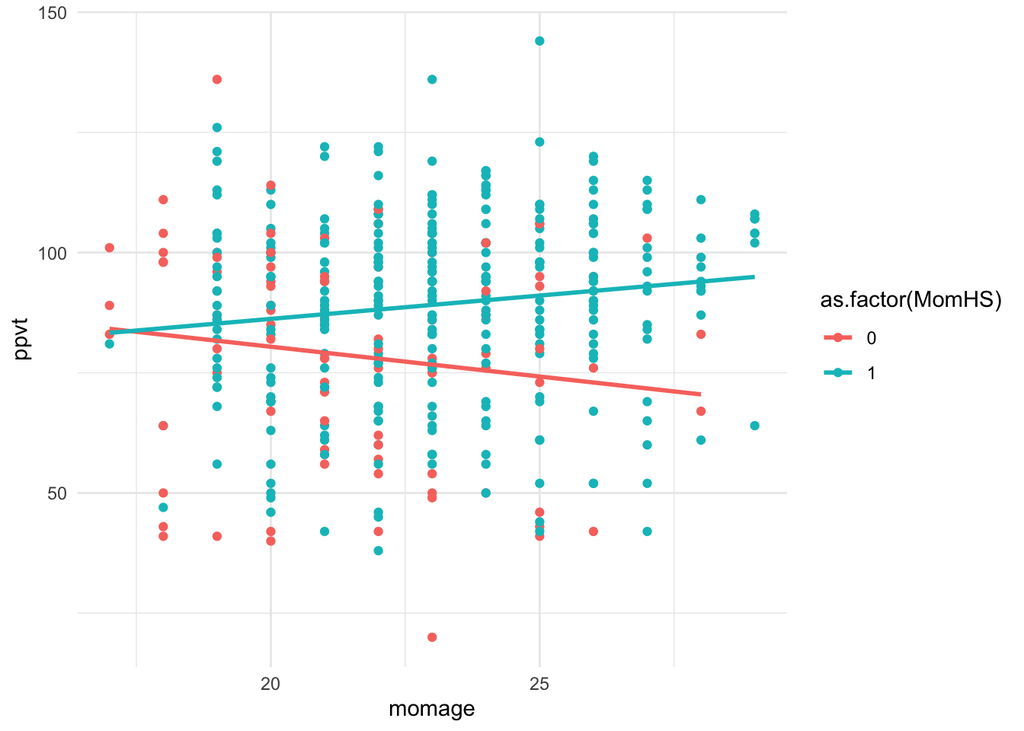

```r
ggplot(KidIQ, aes(x = momage, y = ppvt, color = as.factor(MomHS))) +
  geom_point() +
  geom_smooth(method = "lm", se = FALSE) +
  theme_minimal()
```

### 10.5d

Finally, fit a regression of child test scores on mother’s age and education level for the first 200 children and use this model to predict test scores for the next 200. Graphically display comparisons of the predicted and actual scores for the final 200 children.

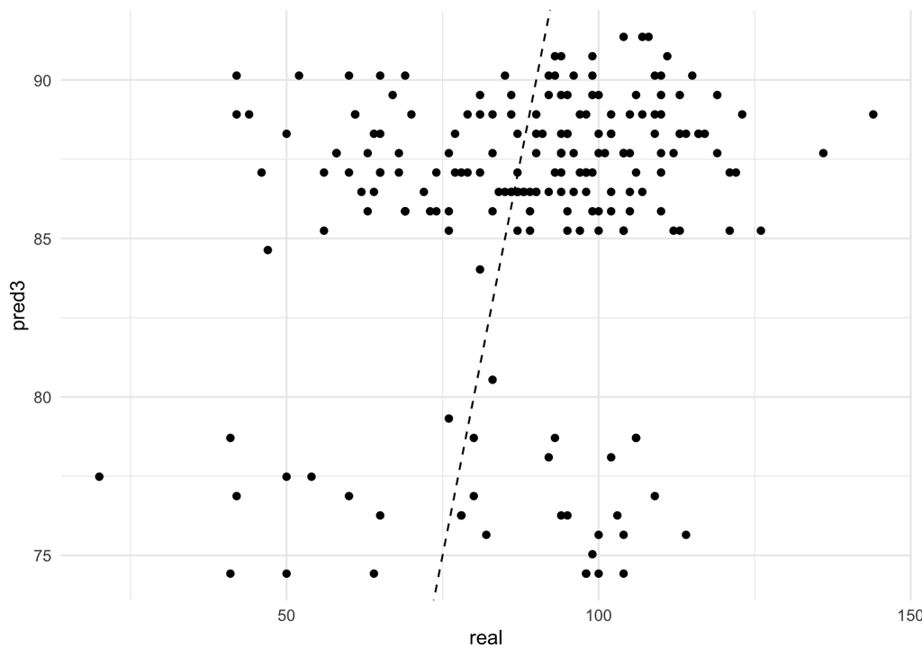

```r
train<-KidIQ[1:200,]
test<-KidIQ[201:400,]

train_mod<-lm(ppvt~momage+MomHS, data = train)
pred3<-predict(train_mod, newdata = test)
Q10.5 <-data.frame(real = test$ppvt, pred = pred3)

ggplot(Q10.5, aes(x = real, y = pred3)) +
  geom_point() +
  geom_abline(slope =1, linetype = "dashed")+
  theme_minimal()
```

## 10.6 Regression models with interactions:

The folder `Beauty` contains data (use file `beauty.csv`) from Hamermesh and Parker (2005) on student evaluations of instructors’ beauty and teaching quality for several courses at the University of Texas. The teaching evaluations were conducted at the end of the semester, and the beauty judgments were made later, by six students who had not attended the classes and were not aware of the course evaluations.

See also Felton, Mitchell, and Stinson (2003) for more on this topic.

```r
beauty<-read.csv("~/Downloads/beauty.csv")
```

### 10.6a

```r
model10.6a <- rstanarm::stan_glm(eval ~ beauty + minority + age + female+ nonenglish+ lower + course_id, data = beauty)
summary(model10.6a)
```

```
##
## Model Info:
##  function:     stan_glm
##  family:       gaussian [identity]
##  formula:      eval ~ beauty + minority + age + female + nonenglish + lower +
##     course_id
##  algorithm:    sampling
##  sample:       4000 (posterior sample size)
##  priors:       see help('prior_summary')
##  observations: 463
##  predictors:   8
##
## Estimates:
##               mean   sd   10%   50%   90%
## (Intercept)  4.2    0.1  4.0   4.2   4.4
## beauty       0.1    0.0  0.1   0.1   0.2
## minority    -0.1    0.1 -0.2  -0.1   0.0
## age          0.0    0.0  0.0   0.0   0.0
## female      -0.2    0.1 -0.3  -0.2  -0.1
## nonenglish  -0.3    0.1 -0.4  -0.3  -0.1
## lower        0.1    0.1  0.0   0.1   0.2
## course_id    0.0    0.0  0.0   0.0   0.0
## sigma        0.5    0.0  0.5   0.5   0.6
##
## Fit Diagnostics:
##            mean   sd   10%   50%   90%
## mean_PPD 4.0    0.0  4.0   4.0   4.0
##
## The mean_ppd is the sample average posterior predictive distribution of the outcome variable (for details see help('summary.stanreg')).
##
## MCMC diagnostics
##               mcse Rhat n_eff
## (Intercept)   0.0  1.0  4128
## beauty        0.0  1.0  3949
## minority      0.0  1.0  3773
## age           0.0  1.0  4329
## female        0.0  1.0  3837
## nonenglish    0.0  1.0  3918
## lower         0.0  1.0  3937
## course_id     0.0  1.0  4275
## sigma         0.0  1.0  4120
## mean_PPD      0.0  1.0  4499
## log-posterior 0.1  1.0  1374
##
## For each parameter, mcse is Monte Carlo standard error, n_eff is a crude measure of effective sample size, and Rhat is the potential scale reduction factor on split chains (at convergence Rhat=1).
```

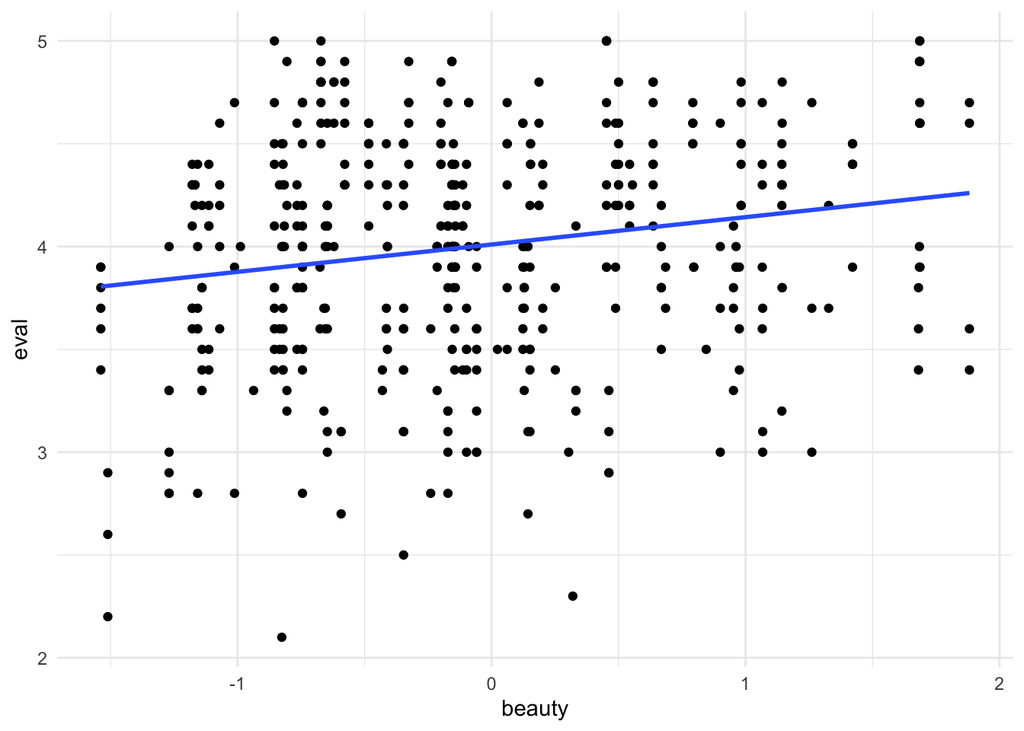

```r
ggplot(beauty, aes(x = beauty, y = eval)) +
  geom_point() +
  geom_smooth(method = "lm", se = FALSE) +
  theme_minimal()
```

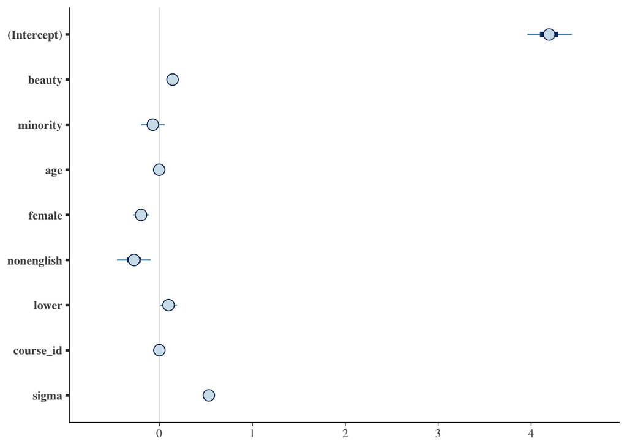

```r
plot(model10.6a, which = 1)
```

```r
res_sd<-summary(model10.6a$sigma)
res_sd
```

```
## Length  Class   Mode
##      0   NULL   NULL
```

### 10.6b

Fit some other models, including beauty and also other predictors. Consider at least one model with interactions. For each model, explain the meaning of each of its estimated coefficients.

For the first model, each increase in beauty rating increases the evaluation by 0.19 on average. If the instructor is female the evaluation decreases by 0.21 on average. For each year older the instructor is the evaluation decreases by 0.002 on average. When the instructor is female, each increase of their beauty rating decreases the evaluation by 0.108 on average.

For the second model, an increase on the beauty scale increases the evaluation by 0.17 on average. If the instructor is a minority, the evaluation decreases by 0.14 on average. For each increase in age of the instructor, the evaluation increases by 0.0002 on average. If the instructor is a minority, each increase in their beauty rating decreases the evaluation by 0.249 on average.

For the third model, each increase in beauty rating increases the evaluation by 0.2 on average. If the instructor is female the evaluation decreases by 0.20 on average. For each year older the instructor is the evaluation decreases by 0.00 on average. When instructor is a non native english speaker the evaluation decreases by 0.3 on average. When the instructor is female, each increase of their beauty rating decreases the evaluation by 0.1 on average.

```r
model10.6b1 <- lm(eval ~ beauty*female + age, data = beauty)
summary(model10.6b1)
```

```
##
## Call:
## lm(formula = eval ~ beauty * female + age, data = beauty)
##
## Residuals:
##      Min       1Q   Median       3Q      Max
## -1.82653 -0.36655  0.03936  0.40393  1.07473
##
## Coefficients:
##                Estimate Std. Error t value Pr(>|t|)
## (Intercept)    4.211270   0.142782  29.494  < 2e-16 ***
## beauty         0.190944   0.044990   4.244 2.66e-05 ***
## female        -0.215483   0.052795  -4.082 5.28e-05 ***
## age           -0.002153   0.002776  -0.776   0.4384
## beauty:female -0.107849   0.064303  -1.677   0.0942 .
## ---
## Signif. codes:  0 '***' 0.001 '**' 0.01 '*' 0.05 '.' 0.1 ' ' 1
##
## Residual standard error: 0.5363 on 458 degrees of freedom
## Multiple R-squared:  0.07378,    Adjusted R-squared:  0.06569
## F-statistic:  9.12 on 4 and 458 DF,  p-value: 4.271e-07
```

```r
model10.6b2 <- lm(eval ~ beauty*minority + age, data = beauty)
summary(model10.6b2)
```

```
##
## Call:
## lm(formula = eval ~ beauty * minority + age, data = beauty)
##
## Residuals:
##     Min      1Q  Median      3Q     Max
## -1.7969 -0.3500  0.0808  0.3970  1.1086
##
## Coefficients:
##                   Estimate Std. Error t value Pr(>|t|)
## (Intercept)      4.0172385  0.1339840  29.983  < 2e-16 ***
## beauty           0.1670256  0.0358138   4.664 4.08e-06 ***
## minority        -0.1406460  0.0733392  -1.918   0.0558 .
## age              0.0002983  0.0027115   0.110   0.9124
## beauty:minority -0.2493286  0.0970901  -2.568   0.0105 *
## ---
## Signif. codes:  0 '***' 0.001 '**' 0.01 '*' 0.05 '.' 0.1 ' ' 1
##
## Residual standard error: 0.5414 on 458 degrees of freedom
## Multiple R-squared:  0.05622,    Adjusted R-squared:  0.04797
## F-statistic:  6.82 on 4 and 458 DF,  p-value: 2.443e-05
```

```r
model10.6b3<-rstanarm::stan_glm(eval ~ beauty*female + age+nonenglish, data = beauty)
summary(model10.6b3)
```

```
##
## Model Info:
##  function:     stan_glm
##  family:       gaussian [identity]
##  formula:      eval ~ beauty * female + age + nonenglish
##  algorithm:    sampling
##  sample:       4000 (posterior sample size)
##  priors:       see help('prior_summary')
##  observations: 463
##  predictors:   6
##
## Estimates:
##                 mean   sd   10%   50%   90%
## (Intercept)    4.2    0.1  4.0   4.2   4.4
## beauty         0.2    0.0  0.1   0.2   0.3
## female        -0.2    0.1 -0.3  -0.2  -0.2
## age            0.0    0.0  0.0   0.0   0.0
## nonenglish    -0.3    0.1 -0.5  -0.3  -0.2
## beauty:female -0.1    0.1 -0.2  -0.1   0.0
## sigma          0.5    0.0  0.5   0.5   0.6
##
## Fit Diagnostics:
##            mean   sd   10%   50%   90%
## mean_PPD 4.0    0.0  4.0   4.0   4.0
##
## The mean_ppd is the sample average posterior predictive distribution of the outcome variable (for details see help('summary.stanreg')).
##
## MCMC diagnostics
##               mcse Rhat n_eff
## (Intercept)   0.0  1.0  3914
## beauty        0.0  1.0  2821
## female        0.0  1.0  4044
## age           0.0  1.0  4067
## nonenglish    0.0  1.0  4310
## beauty:female 0.0  1.0  2761
## sigma         0.0  1.0  4240
## mean_PPD      0.0  1.0  3928
## log-posterior 0.0  1.0  1681
##
## For each parameter, mcse is Monte Carlo standard error, n_eff is a crude measure of effective sample size, and Rhat is the potential scale reduction factor on split chains (at convergence Rhat=1).
```

## 10.7 Predictive simulation for linear regression:

Take one of the models from the previous exercise.

### 10.7a

Instructor A is a 50-year-old woman who is a native English speaker and has a beauty score of -1. Instructor B is a 60-year-old man who is a native English speaker and has a beauty score of -0.5. Simulate 1000 random draws of the course evaluation rating of these two instructors. In your simulation, use `posterior_predict` to account for the uncertainty in the regression parameters as well as predictive uncertainty.

```r
Q10.7a<-data.frame(beauty = c(-1, -0.5),
  age = c(50, 60),
  female = c(1, 0),
  nonenglish = c(0,0))
pred4<-rstanarm::posterior_predict(model10.6b3, newdata = Q10.7a, nsamples = 1000)
```

### 10.7b

Make a histogram of the difference between the course evaluations for A and B. What is the probability that A will have a higher evaluation?

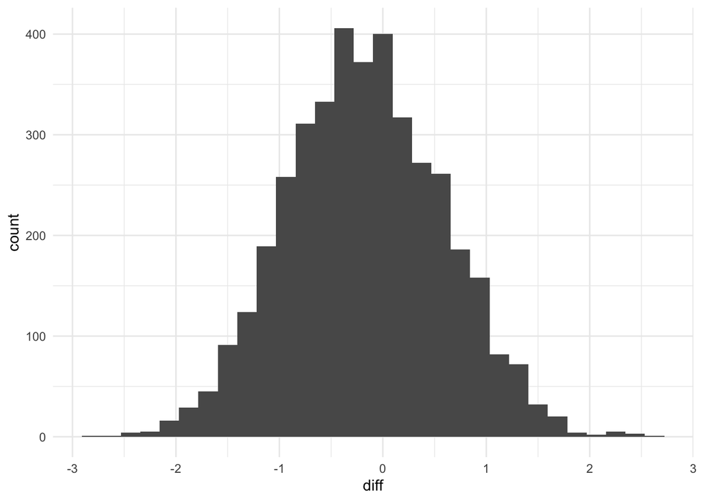

```r
pred_df<-as.data.frame(pred4)
names(pred_df)<-c("inst_A", "inst_B")


pred_df$diff<-pred_df$inst_A - pred_df$inst_B

ggplot(pred_df, aes(x = diff)) +
  geom_histogram(bins = 30) +
  theme_minimal()
```

```r
prob_A<- mean(pred_df$diff > 0)
prob_A
```

```
## [1] 0.40725
```

## 10.8 How many simulation draws:

Take the model from Exercise 10.6 that predicts course evaluations from beauty and other predictors.

### 10.8a

Display and discuss the fitted model. Focus on the estimate and standard error for the coefficient of beauty. The coefficient is 0.1 for beauty, which is rather small, but the standard error is much smaller, which indicates that this estimate is precise and not prone to high variability.

```r
summary(model10.6a)
```

```
##
## Model Info:
##  function:     stan_glm
##  family:       gaussian [identity]
##  formula:      eval ~ beauty + minority + age + female + nonenglish + lower +
##     course_id
##  algorithm:    sampling
##  sample:       4000 (posterior sample size)
##  priors:       see help('prior_summary')
##  observations: 463
##  predictors:   8
##
## Estimates:
##               mean   sd   10%   50%   90%
## (Intercept)  4.2    0.1  4.0   4.2   4.4
## beauty       0.1    0.0  0.1   0.1   0.2
## minority    -0.1    0.1 -0.2  -0.1   0.0
## age          0.0    0.0  0.0   0.0   0.0
## female      -0.2    0.1 -0.3  -0.2  -0.1
## nonenglish  -0.3    0.1 -0.4  -0.3  -0.1
## lower        0.1    0.1  0.0   0.1   0.2
## course_id    0.0    0.0  0.0   0.0   0.0
## sigma        0.5    0.0  0.5   0.5   0.6
##
## Fit Diagnostics:
##            mean   sd   10%   50%   90%
## mean_PPD 4.0    0.0  4.0   4.0   4.0
##
## The mean_ppd is the sample average posterior predictive distribution of the outcome variable (for details see help('summary.stanreg')).
##
## MCMC diagnostics
##               mcse Rhat n_eff
## (Intercept)   0.0  1.0  4128
## beauty        0.0  1.0  3949
## minority      0.0  1.0  3773
## age           0.0  1.0  4329
## female        0.0  1.0  3837
## nonenglish    0.0  1.0  3918
## lower         0.0  1.0  3937
## course_id     0.0  1.0  4275
## sigma         0.0  1.0  4120
## mean_PPD      0.0  1.0  4499
## log-posterior 0.1  1.0  1374
##
## For each parameter, mcse is Monte Carlo standard error, n_eff is a crude measure of effective sample size, and Rhat is the potential scale reduction factor on split chains (at convergence Rhat=1).
```

### 10.8b

Compute the median and mad sd of the posterior simulations of the coefficient of beauty, and check that these are the same as the output from printing the fit.

```r
post_sample<-as.matrix(model10.6a)
beauty_sample<-post_sample[, "beauty"]
median_beauty <- median(beauty_sample)
mad_beauty <- mad(beauty_sample)

median_beauty
```

```
## [1] 0.1413626
```

```r
mad_beauty
```

```
## [1] 0.03198245
```

### 10.8c

Fit again, this time setting `iter` = 1000 in your `stan_glm` call. Do this a few times in order to get a sense of the simulation variability.

```r
fit_model <- function(data) {
  model <- stan_glm(
    eval ~ beauty + minority + age + female + nonenglish + lower + course_id,
    data = data,
    iter = 1000
  )
  post_sample <- as.matrix(model)
  return(post_sample[, "beauty"])
}
n_repeats<-3
all_samples<-lapply(1:n_repeats, function(x) fit_model(beauty))
samples_matrix<- do.call(cbind, all_samples)

median_samples <- apply(samples_matrix, 2, median)
mad_samples <- apply(samples_matrix, 2, mad)
mean_sd_samples <- apply(samples_matrix, 2, sd)
print(c(median_samples, mad_samples, mean_sd_samples))
```

```
## [1] 0.14225744 0.14086500 0.14056549 0.03305474 0.03283263 0.03274143 0.03296211
## [8] 0.03297099 0.03321619
```

### 10.8d

Repeat the previous step, setting `iter` = 100 and then `iter` = 10.

```r
fit_model <- function(data) {
  model <- stan_glm(
    eval ~ beauty + minority + age + female + nonenglish + lower + course_id,
    data = data,
    iter = 100
  )
  post_sample <- as.matrix(model)
  return(post_sample[, "beauty"])
}
n_repeats<-3
all_samples<-lapply(1:n_repeats, function(x) fit_model(beauty))
samples_matrix<- do.call(cbind, all_samples)

median_samples <- apply(samples_matrix, 2, median)
mad_samples <- apply(samples_matrix, 2, mad)
mean_sd_samples <- apply(samples_matrix, 2, sd)
print(c(median_samples, mad_samples, mean_sd_samples))
```

```
## [1] 0.13998060 0.13891033 0.14255701 0.02915219 0.03521925 0.03220110 0.03344564
## [8] 0.03397889 0.03569368
```

```r
fit_model <- function(data) {
  model <- stan_glm(
    eval ~ beauty + minority + age + female + nonenglish + lower + course_id,
    data = data,
    iter = 10
  )
  post_sample <- as.matrix(model)
  return(post_sample[, "beauty"])
}
n_repeats<-3
all_samples<-lapply(1:n_repeats, function(x) fit_model(beauty))
samples_matrix<- do.call(cbind, all_samples)

median_samples <- apply(samples_matrix, 2, median)
mad_samples <- apply(samples_matrix, 2, mad)
mean_sd_samples <- apply(samples_matrix, 2, sd)
print(c(median_samples, mad_samples, mean_sd_samples))
```

```
## [1] -1.0562348 -1.7359282 -0.6311803  1.0054308  1.5897509  0.9388636  0.6752815
## [8]  2.0678876  0.9108668
```

### 10.8e

How many simulations were needed to give a good approximation to the mean and standard error for the coefficient of beauty? 1000